# Risk Factor Analysis

## Outcome Variable

**Outcome Variable:** y_rate_len

## Predictor Variables

**Intervention Variable:** predfeed6

**Adjustment Set:**

unadjusted

## Stratifying Variables

The analysis was stratified on these variable(s):

- agecat
- studyid
- country

## Data Summary

| agecat | studyid | country | predfeed6 | n_cell | n |
| --- | --- | --- | --- | --- | --- |
| 0-3 months | ki0047075b-MAL-ED | BANGLADESH | 0 | 112 | 233 |
| 0-3 months | ki0047075b-MAL-ED | BANGLADESH | 1 | 121 | 233 |
| 0-3 months | ki0047075b-MAL-ED | BRAZIL | 0 | 148 | 175 |
| 0-3 months | ki0047075b-MAL-ED | BRAZIL | 1 | 27 | 175 |
| 0-3 months | ki0047075b-MAL-ED | INDIA | 0 | 178 | 193 |
| 0-3 months | ki0047075b-MAL-ED | INDIA | 1 | 15 | 193 |
| 0-3 months | ki0047075b-MAL-ED | NEPAL | 0 | 150 | 173 |
| 0-3 months | ki0047075b-MAL-ED | NEPAL | 1 | 23 | 173 |
| 0-3 months | ki0047075b-MAL-ED | PERU | 0 | 150 | 258 |
| 0-3 months | ki0047075b-MAL-ED | PERU | 1 | 108 | 258 |
| 0-3 months | ki0047075b-MAL-ED | SOUTH AFRICA | 0 | 206 | 209 |
| 0-3 months | ki0047075b-MAL-ED | SOUTH AFRICA | 1 | 3 | 209 |
| 0-3 months | ki0047075b-MAL-ED | TANZANIA, UNITED REPUBLIC OF | 0 | 223 | 224 |
| 0-3 months | ki0047075b-MAL-ED | TANZANIA, UNITED REPUBLIC OF | 1 | 1 | 224 |
| 0-3 months | ki1000109-EE | PAKISTAN | 0 | 260 | 594 |
| 0-3 months | ki1000109-EE | PAKISTAN | 1 | 334 | 594 |
| 0-3 months | kiGH5241-JiVitA-3 | BANGLADESH | 0 | 8676 | 40078 |
| 0-3 months | kiGH5241-JiVitA-3 | BANGLADESH | 1 | 31402 | 40078 |
| 0-3 months | kiGH5241-JiVitA-4 | BANGLADESH | 0 | 586 | 3610 |
| 0-3 months | kiGH5241-JiVitA-4 | BANGLADESH | 1 | 3024 | 3610 |
| 3-6 months | ki0047075b-MAL-ED | BANGLADESH | 0 | 108 | 225 |
| 3-6 months | ki0047075b-MAL-ED | BANGLADESH | 1 | 117 | 225 |
| 3-6 months | ki0047075b-MAL-ED | BRAZIL | 0 | 173 | 208 |
| 3-6 months | ki0047075b-MAL-ED | BRAZIL | 1 | 35 | 208 |
| 3-6 months | ki0047075b-MAL-ED | INDIA | 0 | 207 | 225 |
| 3-6 months | ki0047075b-MAL-ED | INDIA | 1 | 18 | 225 |
| 3-6 months | ki0047075b-MAL-ED | NEPAL | 0 | 205 | 232 |
| 3-6 months | ki0047075b-MAL-ED | NEPAL | 1 | 27 | 232 |
| 3-6 months | ki0047075b-MAL-ED | PERU | 0 | 153 | 264 |
| 3-6 months | ki0047075b-MAL-ED | PERU | 1 | 111 | 264 |

[output cut: 60 more lines]

The following strata were considered:

- agecat: 0-3 months, studyid: ki0047075b-MAL-ED, country: BANGLADESH
- agecat: 0-3 months, studyid: ki0047075b-MAL-ED, country: BRAZIL
- agecat: 0-3 months, studyid: ki0047075b-MAL-ED, country: INDIA
- agecat: 0-3 months, studyid: ki0047075b-MAL-ED, country: NEPAL
- agecat: 0-3 months, studyid: ki0047075b-MAL-ED, country: PERU
- agecat: 0-3 months, studyid: ki0047075b-MAL-ED, country: SOUTH AFRICA
- agecat: 0-3 months, studyid: ki0047075b-MAL-ED, country: TANZANIA, UNITED REPUBLIC OF
- agecat: 0-3 months, studyid: ki1000109-EE, country: PAKISTAN
- agecat: 0-3 months, studyid: kiGH5241-JiVitA-3, country: BANGLADESH
- agecat: 0-3 months, studyid: kiGH5241-JiVitA-4, country: BANGLADESH
- agecat: 12-24 months, studyid: ki0047075b-MAL-ED, country: BANGLADESH
- agecat: 12-24 months, studyid: ki0047075b-MAL-ED, country: BRAZIL
- agecat: 12-24 months, studyid: ki0047075b-MAL-ED, country: INDIA
- agecat: 12-24 months, studyid: ki0047075b-MAL-ED, country: NEPAL
- agecat: 12-24 months, studyid: ki0047075b-MAL-ED, country: PERU
- agecat: 12-24 months, studyid: ki0047075b-MAL-ED, country: SOUTH AFRICA
- agecat: 12-24 months, studyid: ki0047075b-MAL-ED, country: TANZANIA, UNITED REPUBLIC OF
- agecat: 12-24 months, studyid: ki1113344-GMS-Nepal, country: NEPAL
- agecat: 12-24 months, studyid: ki1148112-LCNI-5, country: MALAWI
- agecat: 12-24 months, studyid: kiGH5241-JiVitA-3, country: BANGLADESH
- agecat: 12-24 months, studyid: kiGH5241-JiVitA-4, country: BANGLADESH
- agecat: 3-6 months, studyid: ki0047075b-MAL-ED, country: BANGLADESH
- agecat: 3-6 months, studyid: ki0047075b-MAL-ED, country: BRAZIL
- agecat: 3-6 months, studyid: ki0047075b-MAL-ED, country: INDIA
- agecat: 3-6 months, studyid: ki0047075b-MAL-ED, country: NEPAL
- agecat: 3-6 months, studyid: ki0047075b-MAL-ED, country: PERU
- agecat: 3-6 months, studyid: ki0047075b-MAL-ED, country: SOUTH AFRICA
- agecat: 3-6 months, studyid: ki0047075b-MAL-ED, country: TANZANIA, UNITED REPUBLIC OF
- agecat: 3-6 months, studyid: ki1000109-EE, country: PAKISTAN
- agecat: 3-6 months, studyid: ki1113344-GMS-Nepal, country: NEPAL
- agecat: 3-6 months, studyid: kiGH5241-JiVitA-3, country: BANGLADESH
- agecat: 3-6 months, studyid: kiGH5241-JiVitA-4, country: BANGLADESH
- agecat: 6-12 months, studyid: ki0047075b-MAL-ED, country: BANGLADESH
- agecat: 6-12 months, studyid: ki0047075b-MAL-ED, country: BRAZIL
- agecat: 6-12 months, studyid: ki0047075b-MAL-ED, country: INDIA
- agecat: 6-12 months, studyid: ki0047075b-MAL-ED, country: NEPAL
- agecat: 6-12 months, studyid: ki0047075b-MAL-ED, country: PERU
- agecat: 6-12 months, studyid: ki0047075b-MAL-ED, country: SOUTH AFRICA
- agecat: 6-12 months, studyid: ki0047075b-MAL-ED, country: TANZANIA, UNITED REPUBLIC OF
- agecat: 6-12 months, studyid: ki1000109-EE, country: PAKISTAN
- agecat: 6-12 months, studyid: ki1000304b-SAS-FoodSuppl, country: INDIA
- agecat: 6-12 months, studyid: ki1113344-GMS-Nepal, country: NEPAL
- agecat: 6-12 months, studyid: ki1148112-LCNI-5, country: MALAWI
- agecat: 6-12 months, studyid: kiGH5241-JiVitA-3, country: BANGLADESH
- agecat: 6-12 months, studyid: kiGH5241-JiVitA-4, country: BANGLADESH

### Dropped Strata

Some strata were dropped due to rare outcomes:

- agecat: 0-3 months, studyid: ki0047075b-MAL-ED, country: SOUTH AFRICA
- agecat: 0-3 months, studyid: ki0047075b-MAL-ED, country: TANZANIA, UNITED REPUBLIC OF
- agecat: 3-6 months, studyid: ki0047075b-MAL-ED, country: SOUTH AFRICA
- agecat: 3-6 months, studyid: ki0047075b-MAL-ED, country: TANZANIA, UNITED REPUBLIC OF
- agecat: 6-12 months, studyid: ki0047075b-MAL-ED, country: SOUTH AFRICA
- agecat: 6-12 months, studyid: ki0047075b-MAL-ED, country: TANZANIA, UNITED REPUBLIC OF
- agecat: 6-12 months, studyid: ki1000109-EE, country: PAKISTAN
- agecat: 6-12 months, studyid: ki1000304b-SAS-FoodSuppl, country: INDIA
- agecat: 12-24 months, studyid: ki0047075b-MAL-ED, country: SOUTH AFRICA
- agecat: 12-24 months, studyid: ki0047075b-MAL-ED, country: TANZANIA, UNITED REPUBLIC OF

## Methods Detail

We’re interested in the causal parameters $E[Y_a]$ for all values of $a \in \mathcal{A}$. These parameters represent the mean outcome if, possibly contrary to fact, we intervened to set all units to have $A=a$. Under the randomization and positivity assumptions, these are identified by the statistical parameters $\psi_a=E_W[E_{Y|A,W}(Y|A=a,W)]$. In addition, we’re interested in the mean of $Y$, $E[Y]$ under no intervention (the observed mean). We will estimate these parameters by using SuperLearner to fit the relevant likelihood factors – $E_{Y|A,W}(Y|A=a,W)$ and $p(A=a|W)$, and then updating our likelihood fit using a joint TMLE.

For unadjusted analyses ($W=\{\}$), initial likelihoods were estimated using Lrnr_glm to estimate the simple $E(Y|A)$ and Lrnr_mean to estimate $p(A)$. For adjusted analyses, a small library containing Lrnr_glmnet, Lrnr_xgboost, and Lrnr_mean was used.

Having estimated these parameters, we will then use the delta method to estimate relative risks and attributable risks relative to a prespecified baseline level of $A$.

# Results Detail

## Results Plots

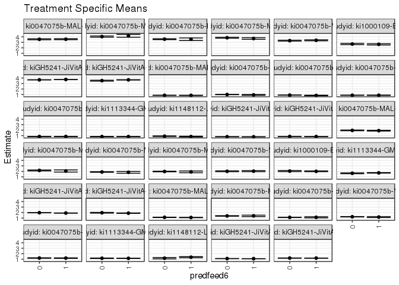

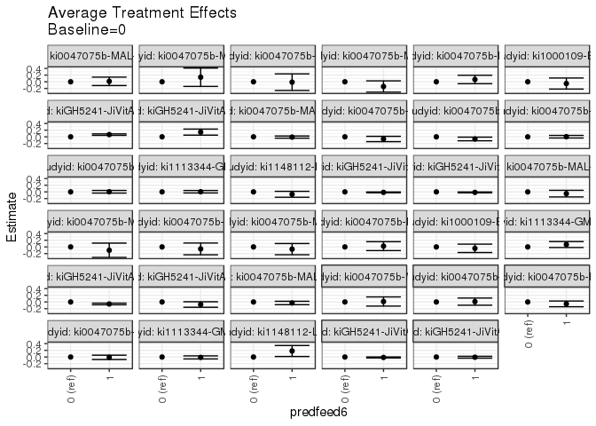

## Results Table

### Parameter: TSM

| agecat | studyid | country | intervention_level | baseline_level | estimate | ci_lower | ci_upper |
| --- | --- | --- | --- | --- | --- | --- | --- |
| 0-3 months | ki0047075b-MAL-ED | BANGLADESH | 0 | NA | 3.5486159 | 3.4583033 | 3.6389286 |
| 0-3 months | ki0047075b-MAL-ED | BANGLADESH | 1 | NA | 3.5616501 | 3.4729604 | 3.6503398 |
| 0-3 months | ki0047075b-MAL-ED | BRAZIL | 0 | NA | 4.0478427 | 3.9361684 | 4.1595169 |
| 0-3 months | ki0047075b-MAL-ED | BRAZIL | 1 | NA | 4.1842288 | 3.9325809 | 4.4358766 |
| 0-3 months | ki0047075b-MAL-ED | INDIA | 0 | NA | 3.5738245 | 3.4925243 | 3.6551246 |
| 0-3 months | ki0047075b-MAL-ED | INDIA | 1 | NA | 3.5624008 | 3.3271436 | 3.7976581 |
| 0-3 months | ki0047075b-MAL-ED | NEPAL | 0 | NA | 3.8359664 | 3.7507357 | 3.9211971 |
| 0-3 months | ki0047075b-MAL-ED | NEPAL | 1 | NA | 3.6938626 | 3.5473218 | 3.8404035 |
| 0-3 months | ki0047075b-MAL-ED | PERU | 0 | NA | 3.3030980 | 3.2194181 | 3.3867778 |
| 0-3 months | ki0047075b-MAL-ED | PERU | 1 | NA | 3.3717477 | 3.2771598 | 3.4663356 |
| 0-3 months | ki1000109-EE | PAKISTAN | 0 | NA | 2.6873656 | 2.5712919 | 2.8034393 |
| 0-3 months | ki1000109-EE | PAKISTAN | 1 | NA | 2.6343660 | 2.5164888 | 2.7522433 |
| 0-3 months | kiGH5241-JiVitA-3 | BANGLADESH | 0 | NA | 3.6660172 | 3.6454716 | 3.6865627 |
| 0-3 months | kiGH5241-JiVitA-3 | BANGLADESH | 1 | NA | 3.7330057 | 3.7217202 | 3.7442912 |
| 0-3 months | kiGH5241-JiVitA-4 | BANGLADESH | 0 | NA | 3.5201919 | 3.4352389 | 3.6051449 |
| 0-3 months | kiGH5241-JiVitA-4 | BANGLADESH | 1 | NA | 3.6616461 | 3.6285286 | 3.6947636 |
| 3-6 months | ki0047075b-MAL-ED | BANGLADESH | 0 | NA | 1.9617396 | 1.8900932 | 2.0333859 |
| 3-6 months | ki0047075b-MAL-ED | BANGLADESH | 1 | NA | 1.9091421 | 1.8398451 | 1.9784392 |
| 3-6 months | ki0047075b-MAL-ED | BRAZIL | 0 | NA | 2.1647058 | 2.0784176 | 2.2509941 |
| 3-6 months | ki0047075b-MAL-ED | BRAZIL | 1 | NA | 2.0643296 | 1.8678954 | 2.2607638 |
| 3-6 months | ki0047075b-MAL-ED | INDIA | 0 | NA | 1.8886636 | 1.8227391 | 1.9545881 |
| 3-6 months | ki0047075b-MAL-ED | INDIA | 1 | NA | 1.8292377 | 1.6653601 | 1.9931152 |
| 3-6 months | ki0047075b-MAL-ED | NEPAL | 0 | NA | 1.9751011 | 1.9149170 | 2.0352853 |
| 3-6 months | ki0047075b-MAL-ED | NEPAL | 1 | NA | 1.9086018 | 1.7518709 | 2.0653327 |
| 3-6 months | ki0047075b-MAL-ED | PERU | 0 | NA | 2.0110077 | 1.9247047 | 2.0973107 |
| 3-6 months | ki0047075b-MAL-ED | PERU | 1 | NA | 2.0342187 | 1.9326186 | 2.1358188 |
| 3-6 months | ki1000109-EE | PAKISTAN | 0 | NA | 2.0488775 | 1.9477119 | 2.1500432 |
| 3-6 months | ki1000109-EE | PAKISTAN | 1 | NA | 2.0061968 | 1.9321154 | 2.0802783 |
| 3-6 months | ki1113344-GMS-Nepal | NEPAL | 0 | NA | 1.6532466 | 1.5763967 | 1.7300966 |
| 3-6 months | ki1113344-GMS-Nepal | NEPAL | 1 | NA | 1.7241137 | 1.6784916 | 1.7697358 |
| 3-6 months | kiGH5241-JiVitA-3 | BANGLADESH | 0 | NA | 1.9676017 | 1.9449187 | 1.9902847 |
| 3-6 months | kiGH5241-JiVitA-3 | BANGLADESH | 1 | NA | 1.9072371 | 1.8958156 | 1.9186585 |
| 3-6 months | kiGH5241-JiVitA-4 | BANGLADESH | 0 | NA | 1.9602485 | 1.8849639 | 2.0355331 |
| 3-6 months | kiGH5241-JiVitA-4 | BANGLADESH | 1 | NA | 1.8843296 | 1.8513594 | 1.9172998 |
| 6-12 months | ki0047075b-MAL-ED | BANGLADESH | 0 | NA | 1.1290419 | 1.0911299 | 1.1669539 |
| 6-12 months | ki0047075b-MAL-ED | BANGLADESH | 1 | NA | 1.0986966 | 1.0648160 | 1.1325772 |
| 6-12 months | ki0047075b-MAL-ED | BRAZIL | 0 | NA | 1.3840529 | 1.3348618 | 1.4332440 |
| 6-12 months | ki0047075b-MAL-ED | BRAZIL | 1 | NA | 1.3975359 | 1.2687654 | 1.5263065 |
| 6-12 months | ki0047075b-MAL-ED | INDIA | 0 | NA | 1.1206680 | 1.0906806 | 1.1506554 |
| 6-12 months | ki0047075b-MAL-ED | INDIA | 1 | NA | 1.1308845 | 1.0275468 | 1.2342221 |
| 6-12 months | ki0047075b-MAL-ED | NEPAL | 0 | NA | 1.2301848 | 1.2031396 | 1.2572300 |
| 6-12 months | ki0047075b-MAL-ED | NEPAL | 1 | NA | 1.1728832 | 1.0912162 | 1.2545503 |
| 6-12 months | ki0047075b-MAL-ED | PERU | 0 | NA | 1.2123065 | 1.1656887 | 1.2589242 |
| 6-12 months | ki0047075b-MAL-ED | PERU | 1 | NA | 1.2025628 | 1.1576524 | 1.2474732 |
| 6-12 months | ki1113344-GMS-Nepal | NEPAL | 0 | NA | 1.1742718 | 1.1338503 | 1.2146932 |
| 6-12 months | ki1113344-GMS-Nepal | NEPAL | 1 | NA | 1.1631189 | 1.1406876 | 1.1855502 |
| 6-12 months | ki1148112-LCNI-5 | MALAWI | 0 | NA | 1.1850352 | 1.0606518 | 1.3094187 |
| 6-12 months | ki1148112-LCNI-5 | MALAWI | 1 | NA | 1.3658051 | 1.2577692 | 1.4738411 |
| 6-12 months | kiGH5241-JiVitA-3 | BANGLADESH | 0 | NA | 1.1167923 | 1.1023320 | 1.1312526 |
| 6-12 months | kiGH5241-JiVitA-3 | BANGLADESH | 1 | NA | 1.1040320 | 1.0966585 | 1.1114054 |
| 6-12 months | kiGH5241-JiVitA-4 | BANGLADESH | 0 | NA | 1.2068697 | 1.1815296 | 1.2322099 |
| 6-12 months | kiGH5241-JiVitA-4 | BANGLADESH | 1 | NA | 1.2007972 | 1.1881466 | 1.2134478 |
| 12-24 months | ki0047075b-MAL-ED | BANGLADESH | 0 | NA | 0.8501160 | 0.8267171 | 0.8735149 |
| 12-24 months | ki0047075b-MAL-ED | BANGLADESH | 1 | NA | 0.8418855 | 0.8197364 | 0.8640347 |
| 12-24 months | ki0047075b-MAL-ED | BRAZIL | 0 | NA | 0.9930220 | 0.9593832 | 1.0266608 |
| 12-24 months | ki0047075b-MAL-ED | BRAZIL | 1 | NA | 0.9281741 | 0.8556645 | 1.0006838 |
| 12-24 months | ki0047075b-MAL-ED | INDIA | 0 | NA | 0.8851639 | 0.8668487 | 0.9034791 |
| 12-24 months | ki0047075b-MAL-ED | INDIA | 1 | NA | 0.8211981 | 0.7700568 | 0.8723395 |
| 12-24 months | ki0047075b-MAL-ED | NEPAL | 0 | NA | 0.8606795 | 0.8438673 | 0.8774918 |
| 12-24 months | ki0047075b-MAL-ED | NEPAL | 1 | NA | 0.8641306 | 0.8291974 | 0.8990638 |
| 12-24 months | ki0047075b-MAL-ED | PERU | 0 | NA | 0.8483564 | 0.8200204 | 0.8766924 |
| 12-24 months | ki0047075b-MAL-ED | PERU | 1 | NA | 0.8518272 | 0.8234288 | 0.8802256 |
| 12-24 months | ki1113344-GMS-Nepal | NEPAL | 0 | NA | 0.8332675 | 0.8007698 | 0.8657651 |
| 12-24 months | ki1113344-GMS-Nepal | NEPAL | 1 | NA | 0.8373310 | 0.8195603 | 0.8551018 |
| 12-24 months | ki1148112-LCNI-5 | MALAWI | 0 | NA | 0.9052456 | 0.8493606 | 0.9611306 |
| 12-24 months | ki1148112-LCNI-5 | MALAWI | 1 | NA | 0.8330056 | 0.7639315 | 0.9020797 |
| 12-24 months | kiGH5241-JiVitA-3 | BANGLADESH | 0 | NA | 0.8075967 | 0.7962702 | 0.8189233 |
| 12-24 months | kiGH5241-JiVitA-3 | BANGLADESH | 1 | NA | 0.7929484 | 0.7872193 | 0.7986776 |
| 12-24 months | kiGH5241-JiVitA-4 | BANGLADESH | 0 | NA | 0.8615346 | 0.8497795 | 0.8732896 |
| 12-24 months | kiGH5241-JiVitA-4 | BANGLADESH | 1 | NA | 0.8456038 | 0.8391329 | 0.8520746 |

### Parameter: E(Y)

| agecat | studyid | country | intervention_level | baseline_level | estimate | ci_lower | ci_upper |
| --- | --- | --- | --- | --- | --- | --- | --- |
| 0-3 months | ki0047075b-MAL-ED | BANGLADESH | NA | NA | 3.5553847 | 3.4920868 | 3.6186827 |
| 0-3 months | ki0047075b-MAL-ED | BRAZIL | NA | NA | 4.0688851 | 3.9665094 | 4.1712608 |
| 0-3 months | ki0047075b-MAL-ED | INDIA | NA | NA | 3.5729366 | 3.4957568 | 3.6501164 |
| 0-3 months | ki0047075b-MAL-ED | NEPAL | NA | NA | 3.8170740 | 3.7403102 | 3.8938378 |
| 0-3 months | ki0047075b-MAL-ED | PERU | NA | NA | 3.3318351 | 3.2689715 | 3.3946986 |
| 0-3 months | ki1000109-EE | PAKISTAN | NA | NA | 2.6575645 | 2.5739973 | 2.7411317 |
| 0-3 months | kiGH5241-JiVitA-3 | BANGLADESH | NA | NA | 3.7185042 | 3.7081620 | 3.7288464 |
| 0-3 months | kiGH5241-JiVitA-4 | BANGLADESH | NA | NA | 3.6386843 | 3.6074983 | 3.6698703 |
| 3-6 months | ki0047075b-MAL-ED | BANGLADESH | NA | NA | 1.9343889 | 1.8844588 | 1.9843190 |
| 3-6 months | ki0047075b-MAL-ED | BRAZIL | NA | NA | 2.1478156 | 2.0686357 | 2.2269955 |
| 3-6 months | ki0047075b-MAL-ED | INDIA | NA | NA | 1.8839095 | 1.8218223 | 1.9459968 |
| 3-6 months | ki0047075b-MAL-ED | NEPAL | NA | NA | 1.9673620 | 1.9110737 | 2.0236503 |
| 3-6 months | ki0047075b-MAL-ED | PERU | NA | NA | 2.0207669 | 1.9549762 | 2.0865576 |
| 3-6 months | ki1000109-EE | PAKISTAN | NA | NA | 2.0241201 | 1.9636505 | 2.0845898 |
| 3-6 months | ki1113344-GMS-Nepal | NEPAL | NA | NA | 1.7048001 | 1.6654509 | 1.7441494 |
| 3-6 months | kiGH5241-JiVitA-3 | BANGLADESH | NA | NA | 1.9200510 | 1.9095836 | 1.9305183 |
| 3-6 months | kiGH5241-JiVitA-4 | BANGLADESH | NA | NA | 1.8963650 | 1.8662030 | 1.9265270 |
| 6-12 months | ki0047075b-MAL-ED | BANGLADESH | NA | NA | 1.1131603 | 1.0877615 | 1.1385590 |
| 6-12 months | ki0047075b-MAL-ED | BRAZIL | NA | NA | 1.3863464 | 1.3400121 | 1.4326807 |
| 6-12 months | ki0047075b-MAL-ED | INDIA | NA | NA | 1.1214539 | 1.0926522 | 1.1502556 |
| 6-12 months | ki0047075b-MAL-ED | NEPAL | NA | NA | 1.2234287 | 1.1975908 | 1.2492667 |
| 6-12 months | ki0047075b-MAL-ED | PERU | NA | NA | 1.2081188 | 1.1752622 | 1.2409753 |
| 6-12 months | ki1113344-GMS-Nepal | NEPAL | NA | NA | 1.1659725 | 1.1463312 | 1.1856138 |
| 6-12 months | ki1148112-LCNI-5 | MALAWI | NA | NA | 1.2437855 | 1.1489803 | 1.3385906 |
| 6-12 months | kiGH5241-JiVitA-3 | BANGLADESH | NA | NA | 1.1067177 | 1.0999609 | 1.1134745 |
| 6-12 months | kiGH5241-JiVitA-4 | BANGLADESH | NA | NA | 1.2020599 | 1.1906612 | 1.2134585 |
| 12-24 months | ki0047075b-MAL-ED | BANGLADESH | NA | NA | 0.8457372 | 0.8296411 | 0.8618334 |
| 12-24 months | ki0047075b-MAL-ED | BRAZIL | NA | NA | 0.9816245 | 0.9508764 | 1.0123725 |
| 12-24 months | ki0047075b-MAL-ED | INDIA | NA | NA | 0.8802656 | 0.8627612 | 0.8977700 |
| 12-24 months | ki0047075b-MAL-ED | NEPAL | NA | NA | 0.8610937 | 0.8457157 | 0.8764716 |
| 12-24 months | ki0047075b-MAL-ED | PERU | NA | NA | 0.8498071 | 0.8294861 | 0.8701282 |
| 12-24 months | ki1113344-GMS-Nepal | NEPAL | NA | NA | 0.8363408 | 0.8207398 | 0.8519417 |
| 12-24 months | ki1148112-LCNI-5 | MALAWI | NA | NA | 0.8835736 | 0.8376943 | 0.9294529 |
| 12-24 months | kiGH5241-JiVitA-3 | BANGLADESH | NA | NA | 0.7961667 | 0.7908693 | 0.8014641 |
| 12-24 months | kiGH5241-JiVitA-4 | BANGLADESH | NA | NA | 0.8490267 | 0.8432029 | 0.8548505 |

### Parameter: ATE

| agecat | studyid | country | intervention_level | baseline_level | estimate | ci_lower | ci_upper |
| --- | --- | --- | --- | --- | --- | --- | --- |
| 0-3 months | ki0047075b-MAL-ED | BANGLADESH | 0 | 0 | 0.0000000 | 0.0000000 | 0.0000000 |
| 0-3 months | ki0047075b-MAL-ED | BANGLADESH | 1 | 0 | 0.0130341 | -0.1135448 | 0.1396131 |
| 0-3 months | ki0047075b-MAL-ED | BRAZIL | 0 | 0 | 0.0000000 | 0.0000000 | 0.0000000 |
| 0-3 months | ki0047075b-MAL-ED | BRAZIL | 1 | 0 | 0.1363861 | -0.1389279 | 0.4117001 |
| 0-3 months | ki0047075b-MAL-ED | INDIA | 0 | 0 | 0.0000000 | 0.0000000 | 0.0000000 |
| 0-3 months | ki0047075b-MAL-ED | INDIA | 1 | 0 | -0.0114236 | -0.2603326 | 0.2374853 |
| 0-3 months | ki0047075b-MAL-ED | NEPAL | 0 | 0 | 0.0000000 | 0.0000000 | 0.0000000 |
| 0-3 months | ki0047075b-MAL-ED | NEPAL | 1 | 0 | -0.1421038 | -0.3116281 | 0.0274205 |
| 0-3 months | ki0047075b-MAL-ED | PERU | 0 | 0 | 0.0000000 | 0.0000000 | 0.0000000 |
| 0-3 months | ki0047075b-MAL-ED | PERU | 1 | 0 | 0.0686497 | -0.0576404 | 0.1949398 |
| 0-3 months | ki1000109-EE | PAKISTAN | 0 | 0 | 0.0000000 | 0.0000000 | 0.0000000 |
| 0-3 months | ki1000109-EE | PAKISTAN | 1 | 0 | -0.0529996 | -0.2184328 | 0.1124337 |
| 0-3 months | kiGH5241-JiVitA-3 | BANGLADESH | 0 | 0 | 0.0000000 | 0.0000000 | 0.0000000 |
| 0-3 months | kiGH5241-JiVitA-3 | BANGLADESH | 1 | 0 | 0.0669885 | 0.0447410 | 0.0892361 |
| 0-3 months | kiGH5241-JiVitA-4 | BANGLADESH | 0 | 0 | 0.0000000 | 0.0000000 | 0.0000000 |
| 0-3 months | kiGH5241-JiVitA-4 | BANGLADESH | 1 | 0 | 0.1414542 | 0.0503892 | 0.2325193 |
| 3-6 months | ki0047075b-MAL-ED | BANGLADESH | 0 | 0 | 0.0000000 | 0.0000000 | 0.0000000 |
| 3-6 months | ki0047075b-MAL-ED | BANGLADESH | 1 | 0 | -0.0525974 | -0.1522733 | 0.0470785 |
| 3-6 months | ki0047075b-MAL-ED | BRAZIL | 0 | 0 | 0.0000000 | 0.0000000 | 0.0000000 |
| 3-6 months | ki0047075b-MAL-ED | BRAZIL | 1 | 0 | -0.1003763 | -0.3149271 | 0.1141746 |
| 3-6 months | ki0047075b-MAL-ED | INDIA | 0 | 0 | 0.0000000 | 0.0000000 | 0.0000000 |
| 3-6 months | ki0047075b-MAL-ED | INDIA | 1 | 0 | -0.0594259 | -0.2360665 | 0.1172146 |
| 3-6 months | ki0047075b-MAL-ED | NEPAL | 0 | 0 | 0.0000000 | 0.0000000 | 0.0000000 |
| 3-6 months | ki0047075b-MAL-ED | NEPAL | 1 | 0 | -0.0664993 | -0.2343883 | 0.1013897 |
| 3-6 months | ki0047075b-MAL-ED | PERU | 0 | 0 | 0.0000000 | 0.0000000 | 0.0000000 |
| 3-6 months | ki0047075b-MAL-ED | PERU | 1 | 0 | 0.0232109 | -0.1100962 | 0.1565181 |
| 3-6 months | ki1000109-EE | PAKISTAN | 0 | 0 | 0.0000000 | 0.0000000 | 0.0000000 |
| 3-6 months | ki1000109-EE | PAKISTAN | 1 | 0 | -0.0426807 | -0.1680703 | 0.0827089 |
| 3-6 months | ki1113344-GMS-Nepal | NEPAL | 0 | 0 | 0.0000000 | 0.0000000 | 0.0000000 |
| 3-6 months | ki1113344-GMS-Nepal | NEPAL | 1 | 0 | 0.0708670 | -0.0185046 | 0.1602387 |
| 3-6 months | kiGH5241-JiVitA-3 | BANGLADESH | 0 | 0 | 0.0000000 | 0.0000000 | 0.0000000 |
| 3-6 months | kiGH5241-JiVitA-3 | BANGLADESH | 1 | 0 | -0.0603646 | -0.0851624 | -0.0355668 |
| 3-6 months | kiGH5241-JiVitA-4 | BANGLADESH | 0 | 0 | 0.0000000 | 0.0000000 | 0.0000000 |
| 3-6 months | kiGH5241-JiVitA-4 | BANGLADESH | 1 | 0 | -0.0759189 | -0.1583398 | 0.0065020 |
| 6-12 months | ki0047075b-MAL-ED | BANGLADESH | 0 | 0 | 0.0000000 | 0.0000000 | 0.0000000 |
| 6-12 months | ki0047075b-MAL-ED | BANGLADESH | 1 | 0 | -0.0303453 | -0.0811903 | 0.0204998 |
| 6-12 months | ki0047075b-MAL-ED | BRAZIL | 0 | 0 | 0.0000000 | 0.0000000 | 0.0000000 |
| 6-12 months | ki0047075b-MAL-ED | BRAZIL | 1 | 0 | 0.0134830 | -0.1243634 | 0.1513293 |
| 6-12 months | ki0047075b-MAL-ED | INDIA | 0 | 0 | 0.0000000 | 0.0000000 | 0.0000000 |
| 6-12 months | ki0047075b-MAL-ED | INDIA | 1 | 0 | 0.0102165 | -0.0973843 | 0.1178172 |
| 6-12 months | ki0047075b-MAL-ED | NEPAL | 0 | 0 | 0.0000000 | 0.0000000 | 0.0000000 |
| 6-12 months | ki0047075b-MAL-ED | NEPAL | 1 | 0 | -0.0573016 | -0.1433304 | 0.0287272 |
| 6-12 months | ki0047075b-MAL-ED | PERU | 0 | 0 | 0.0000000 | 0.0000000 | 0.0000000 |
| 6-12 months | ki0047075b-MAL-ED | PERU | 1 | 0 | -0.0097437 | -0.0744751 | 0.0549877 |
| 6-12 months | ki1113344-GMS-Nepal | NEPAL | 0 | 0 | 0.0000000 | 0.0000000 | 0.0000000 |
| 6-12 months | ki1113344-GMS-Nepal | NEPAL | 1 | 0 | -0.0111529 | -0.0573811 | 0.0350754 |
| 6-12 months | ki1148112-LCNI-5 | MALAWI | 0 | 0 | 0.0000000 | 0.0000000 | 0.0000000 |
| 6-12 months | ki1148112-LCNI-5 | MALAWI | 1 | 0 | 0.1807699 | 0.0160186 | 0.3455212 |
| 6-12 months | kiGH5241-JiVitA-3 | BANGLADESH | 0 | 0 | 0.0000000 | 0.0000000 | 0.0000000 |
| 6-12 months | kiGH5241-JiVitA-3 | BANGLADESH | 1 | 0 | -0.0127603 | -0.0285625 | 0.0030419 |
| 6-12 months | kiGH5241-JiVitA-4 | BANGLADESH | 0 | 0 | 0.0000000 | 0.0000000 | 0.0000000 |
| 6-12 months | kiGH5241-JiVitA-4 | BANGLADESH | 1 | 0 | -0.0060725 | -0.0342140 | 0.0220690 |
| 12-24 months | ki0047075b-MAL-ED | BANGLADESH | 0 | 0 | 0.0000000 | 0.0000000 | 0.0000000 |
| 12-24 months | ki0047075b-MAL-ED | BANGLADESH | 1 | 0 | -0.0082305 | -0.0404499 | 0.0239890 |
| 12-24 months | ki0047075b-MAL-ED | BRAZIL | 0 | 0 | 0.0000000 | 0.0000000 | 0.0000000 |
| 12-24 months | ki0047075b-MAL-ED | BRAZIL | 1 | 0 | -0.0648478 | -0.1447804 | 0.0150848 |
| 12-24 months | ki0047075b-MAL-ED | INDIA | 0 | 0 | 0.0000000 | 0.0000000 | 0.0000000 |
| 12-24 months | ki0047075b-MAL-ED | INDIA | 1 | 0 | -0.0639658 | -0.1182878 | -0.0096437 |
| 12-24 months | ki0047075b-MAL-ED | NEPAL | 0 | 0 | 0.0000000 | 0.0000000 | 0.0000000 |
| 12-24 months | ki0047075b-MAL-ED | NEPAL | 1 | 0 | 0.0034510 | -0.0353172 | 0.0422193 |
| 12-24 months | ki0047075b-MAL-ED | PERU | 0 | 0 | 0.0000000 | 0.0000000 | 0.0000000 |
| 12-24 months | ki0047075b-MAL-ED | PERU | 1 | 0 | 0.0034708 | -0.0366465 | 0.0435881 |
| 12-24 months | ki1113344-GMS-Nepal | NEPAL | 0 | 0 | 0.0000000 | 0.0000000 | 0.0000000 |
| 12-24 months | ki1113344-GMS-Nepal | NEPAL | 1 | 0 | 0.0040636 | -0.0329756 | 0.0411027 |
| 12-24 months | ki1148112-LCNI-5 | MALAWI | 0 | 0 | 0.0000000 | 0.0000000 | 0.0000000 |
| 12-24 months | ki1148112-LCNI-5 | MALAWI | 1 | 0 | -0.0722400 | -0.1610902 | 0.0166103 |
| 12-24 months | kiGH5241-JiVitA-3 | BANGLADESH | 0 | 0 | 0.0000000 | 0.0000000 | 0.0000000 |
| 12-24 months | kiGH5241-JiVitA-3 | BANGLADESH | 1 | 0 | -0.0146483 | -0.0269410 | -0.0023556 |
| 12-24 months | kiGH5241-JiVitA-4 | BANGLADESH | 0 | 0 | 0.0000000 | 0.0000000 | 0.0000000 |
| 12-24 months | kiGH5241-JiVitA-4 | BANGLADESH | 1 | 0 | -0.0159308 | -0.0289442 | -0.0029174 |